# AMRS Intercomparison Round 3

## Angular Rate

### Precison

To enable determining the 3-D wind vector with respect to the earth coordinate system, the AMRS shall be capable of measuring angular rates around either of 3 axes with a precision of ≤ 2.0 deg s-1.

Both settings **PASSED**

|  | sensor | measurement | stat | 2021-06-22 | 2021-06-23 | 2021-06-24 | 2021-06-25 | 2021-06-26 | 2021-06-27 | 2021-06-28 | 2021-06-29 | 2021-07-05 | 2021-07-06 | 2021-07-07 | 2021-07-08 | 2021-07-09 | 2021-07-10 | 2021-07-11 | 2021-07-12 | 2021-07-13 | 2021-07-14 | 2021-07-15 | 2021-07-16 | 2021-07-17 | 2021-07-18 | 2021-07-19 | 2021-07-20 | 2021-07-21 | 2021-07-22 | … |
| --- | --- | --- | --- | --- | --- | --- | --- | --- | --- | --- | --- | --- | --- | --- | --- | --- | --- | --- | --- | --- | --- | --- | --- | --- | --- | --- | --- | --- | --- | --- |
| 1 | soniAmrs02 | avelXaxsDeg | prcs | 0.0829389 | 0.1060332 | 0.0857222 | 0.0816698 | 0.0837225 | 0.091756 | 0.0781082 | 0.0781748 | 0.09202 | 0.083808 | 0.082556 | 0.089033 | 0.1114146 | 0.1283157 | 0.0823597 | 0.0931168 | 0.0814906 | 0.098229 | 0.0781399 | 0.0872293 | 0.0821185 | 0.0810518 | 0.0841686 | 0.0802646 | 0.081025 | 0.0858346 | … |
| 2 | soniAmrs02 | avelYaxsDeg | prcs | 0.0781213 | 0.0870245 | 0.0800235 | 0.0756989 | 0.0711603 | 0.0747045 | 0.0731912 | 0.0724687 | 0.0808561 | 0.0772695 | 0.0769893 | 0.0812935 | 0.0886607 | 0.0962375 | 0.0722871 | 0.0852351 | 0.0746667 | 0.0821798 | 0.073873 | 0.0780061 | 0.0757908 | 0.0786203 | 0.0772997 | 0.0772293 | 0.0755774 | 0.0784712 | … |
| 3 | soniAmrs02 | avelZaxsDeg | prcs | 0.076185 | 0.0821265 | 0.0771923 | 0.0720114 | 0.0701783 | 0.0731937 | 0.071878 | 0.0713716 | 0.0800067 | 0.0760959 | 0.0750621 | 0.0795067 | 0.0870622 | 0.0942086 | 0.0711257 | 0.0805376 | 0.0735745 | 0.079334 | 0.0724561 | 0.076667 | 0.0743694 | 0.0744418 | 0.0758078 | 0.0745747 | 0.0747725 | 0.0774583 | … |
| 4 | soniAmrs03 | avelXaxsDeg | prcs | 0.0881321 | 0.0992328 | 0.0885545 | 0.0806353 | 0.0887545 | 0.0913082 | 0.0812653 | 0.0791298 | 0.0855636 |  | 0.0874858 | 0.0924154 | 0.0982983 | 0.0948609 | 0.0860009 | 0.0840837 | 0.0856245 | 0.0993546 | 0.0805812 | 0.0858994 | 0.0852843 | 0.0851037 | 0.0868751 | 0.0837231 | 0.0834038 | 0.0870258 | … |
| 5 | soniAmrs03 | avelYaxsDeg | prcs | 0.0872488 | 0.0916452 | 0.0872225 | 0.0805658 | 0.079891 | 0.0821279 | 0.0811836 | 0.0805289 | 0.0849474 |  | 0.0874101 | 0.08981 | 0.0902082 | 0.0864949 | 0.080715 | 0.0845567 | 0.0846507 | 0.0897514 | 0.0821067 | 0.0844168 | 0.0843018 | 0.0846219 | 0.0855061 | 0.0843161 | 0.0845083 | 0.0858987 | … |
| 6 | soniAmrs03 | avelZaxsDeg | prcs | 0.0750621 | 0.0784492 | 0.0760252 | 0.0699448 | 0.0697756 | 0.072092 | 0.070657 | 0.0704872 | 0.0744234 |  | 0.0758585 | 0.0766681 | 0.0791981 | 0.076591 | 0.0701617 | 0.0752915 | 0.0729819 | 0.0783305 | 0.0706563 | 0.0736507 | 0.0732916 | 0.0726782 | 0.0764423 | 0.0730876 | 0.072223 | 0.0740595 | … |

### Resolution

To enable determining the 3-D wind vector with respect to the earth coordinate system, the AMRS shall be capable of measuring angular rates around either of 3 axes with a resolution of ≤ 0.2 deg s-1.

Both settings **PASSED**

|  | sensor | measurement | stat | 2021-06-22 | 2021-06-23 | 2021-06-24 | 2021-06-25 | 2021-06-26 | 2021-06-27 | 2021-06-28 | 2021-06-29 | 2021-06-30 | 2021-07-01 | 2021-07-02 | 2021-07-03 | 2021-07-04 | 2021-07-05 | 2021-07-06 | 2021-07-07 | 2021-07-08 | 2021-07-09 | 2021-07-10 | 2021-07-11 | 2021-07-12 | 2021-07-13 | 2021-07-14 | 2021-07-15 | 2021-07-16 | 2021-07-17 | … |
| --- | --- | --- | --- | --- | --- | --- | --- | --- | --- | --- | --- | --- | --- | --- | --- | --- | --- | --- | --- | --- | --- | --- | --- | --- | --- | --- | --- | --- | --- | --- |
| 1 | soniAmrs02 | avelXaxsDeg | reso | 0.0580666 | 0.0573818 | 0.0589632 | 0.0499275 | 0.0609747 | 0.0713599 | 0.0516179 | 0.0542393 | 0.0510652 | 0.0499882 | 0.049313 | 0.0523588 | 0.0535151 | 0.0536622 | 0.0533619 | 0.0533201 | 0.0556673 | 0.0721712 | 0.0630159 | 0.0523389 | 0.0533432 | 0.0533433 | 0.05231 | 0.0501696 | 0.0536431 | 0.0538155 | … |
| 2 | soniAmrs02 | avelYaxsDeg | reso | 0.0486546 | 0.0501865 | 0.0529602 | 0.044533 | 0.0435997 | 0.0478927 | 0.04589 | 0.0476345 | 0.0444953 | 0.0446788 | 0.0437491 | 0.0455386 | 0.0462655 | 0.046659 | 0.046745 | 0.0462738 | 0.0479718 | 0.0601964 | 0.0535465 | 0.0443196 | 0.0470476 | 0.0465367 | 0.0457894 | 0.0442531 | 0.0467703 | 0.0467104 | … |
| 3 | soniAmrs02 | avelZaxsDeg | reso | 0.0509735 | 0.0518567 | 0.0558729 | 0.046999 | 0.0459761 | 0.0505685 | 0.0490403 | 0.0503984 | 0.0470434 | 0.0474267 | 0.0462759 | 0.0481351 | 0.0490626 | 0.0495353 | 0.0494256 | 0.0491765 | 0.0506279 | 0.063871 | 0.0571163 | 0.0463872 | 0.0491773 | 0.0491862 | 0.0484848 | 0.0468714 | 0.0498361 | 0.0497639 | … |
| 4 | soniAmrs03 | avelXaxsDeg | reso | 0.0623086 | 0.062051 | 0.063854 | 0.0546146 | 0.0653165 | 0.0746283 | 0.0561954 | 0.0564851 | 0.0556488 | 0.0547202 | 0.0523871 |  |  | 0.0595855 |  | 0.0620543 | 0.0604471 | 0.0769119 | 0.0679695 | 0.0568338 | 0.0574511 | 0.0580509 | 0.0571443 | 0.0549504 | 0.0583744 | 0.0584241 | … |
| 5 | soniAmrs03 | avelYaxsDeg | reso | 0.0598849 | 0.0615397 | 0.0641247 | 0.0556466 | 0.0545542 | 0.0587532 | 0.0569452 | 0.0570968 | 0.0555645 | 0.0558802 | 0.0549952 |  |  | 0.0583065 |  | 0.0596092 | 0.0592677 | 0.0707255 | 0.0650285 | 0.0556146 | 0.0579972 | 0.0576935 | 0.0572258 | 0.0554644 | 0.0580002 | 0.0577835 | … |
| 6 | soniAmrs03 | avelZaxsDeg | reso | 0.048206 | 0.0493313 | 0.0536506 | 0.0447795 | 0.0437992 | 0.0482747 | 0.0469067 | 0.0466056 | 0.0447614 | 0.0450309 | 0.0442678 |  |  | 0.0472706 |  | 0.0482384 | 0.0481948 | 0.0615568 | 0.0546376 | 0.0439296 | 0.0463695 | 0.0468285 | 0.046104 | 0.0445234 | 0.0473389 | 0.0473421 | … |

### Accuracy

To enable determining the 3-D wind vector with respect to the earth coordinate system, the AMRS shall be capable of measuring angular rates around either of 3 axes with an accuracy of ≤ 4.0 deg s-1.

Both settings **PASSED**

|  | sensor | measurement | stat | 2021-06-22 | 2021-06-23 | 2021-06-24 | 2021-06-25 | 2021-06-26 | 2021-06-27 | 2021-06-28 | 2021-06-29 | 2021-07-05 | 2021-07-06 | 2021-07-07 | 2021-07-08 | 2021-07-09 | 2021-07-10 | 2021-07-11 | 2021-07-12 | 2021-07-13 | 2021-07-14 | 2021-07-15 | 2021-07-16 | 2021-07-17 | 2021-07-18 | 2021-07-19 | 2021-07-20 | 2021-07-21 | 2021-07-22 | … |
| --- | --- | --- | --- | --- | --- | --- | --- | --- | --- | --- | --- | --- | --- | --- | --- | --- | --- | --- | --- | --- | --- | --- | --- | --- | --- | --- | --- | --- | --- | --- |
| 1 | soniAmrs02 | avelXaxsDeg | diffMean | 0.0662236 | 0.0501412 | 0.0394081 | 0.0511213 | 0.0467694 | 0.0640225 | 0.0587304 | 0.0382717 | 0.0414154 | 0.026352 | 0.0375545 | 0.0343253 | 0.0401515 | 0.0379744 | 0.0484369 | 0.0555256 | 0.0452855 | 0.0393722 | 0.0390931 | 0.0120929 | 0.0164808 | 0.0131906 | 0.0220115 | 0.0291527 | 0.0289292 | 0.0312761 | … |
| 2 | soniAmrs02 | avelYaxsDeg | diffMean | 0.085213 | 0.0986198 | 0.0930869 | 0.1173973 | 0.0893477 | 0.0644879 | 0.0728383 | 0.0759111 | 0.0634693 | 0.0641992 | 0.078909 | 0.1089655 | 0.1044951 | 0.1124069 | 0.0953376 | 0.0982761 | 0.1005402 | 0.0989673 | 0.099064 | 0.1097812 | 0.1088318 | 0.1142126 | 0.0991229 | 0.0950461 | 0.1030943 | 0.0893909 | … |
| 3 | soniAmrs02 | avelZaxsDeg | diffMean | 0.1894352 | 0.2122144 | 0.2187738 | 0.2190672 | 0.2206322 | 0.2108492 | 0.2227926 | 0.2168502 | 0.1934443 | 0.2103668 | 0.2071284 | 0.212557 | 0.2155785 | 0.2365959 | 0.2410608 | 0.2344474 | 0.226946 | 0.2289958 | 0.2262059 | 0.2216928 | 0.2231866 | 0.2302861 | 0.2275749 | 0.2414893 | 0.2388323 | 0.2195695 | … |
| 4 | soniAmrs03 | avelXaxsDeg | diffMean | 0.3178463 | 0.3356803 | 0.3167479 | 0.3079523 | 0.3391787 | 0.3318414 | 0.3261142 | 0.3281731 | 0.3166397 |  | 0.3105367 | 0.3247188 | 0.3315727 | 0.3300228 | 0.308849 | 0.2841449 | 0.2936484 | 0.3033492 | 0.3086784 | 0.3250301 | 0.3138312 | 0.2959344 | 0.2912275 | 0.2872815 | 0.3042176 | 0.3127232 | … |
| 5 | soniAmrs03 | avelYaxsDeg | diffMean | 0.0474506 | 0.0455006 | 0.0712065 | 0.0431568 | 0.0522828 | 0.0229189 | 0.0427725 | 0.0712889 | 0.0405947 |  | 0.0527403 | 0.0791312 | 0.1101606 | 0.1026365 | 0.0580863 | 0.0961667 | 0.1414186 | 0.124816 | 0.110139 | 0.1021457 | 0.0625785 | 0.0461103 | 0.0399375 | 0.0410738 | 0.0358079 | 0.0449825 | … |
| 6 | soniAmrs03 | avelZaxsDeg | diffMean | 0.1355146 | 0.1408887 | 0.1558217 | 0.1499711 | 0.1379257 | 0.118001 | 0.1261902 | 0.1193835 | 0.1633672 |  | 0.1783819 | 0.210636 | 0.2149266 | 0.2398303 | 0.232523 | 0.2085814 | 0.1966262 | 0.1917619 | 0.2008042 | 0.188993 | 0.1936806 | 0.2128958 | 0.19145 | 0.1670797 | 0.188609 | 0.1684354 | … |

## Angles

### Accuracy of Z-azimuth

To enable determining the 3-D wind vector with respect to the earth coordinate system, the AMRS shall be capable of measuring azimuth (around z-axis) with an accuracy of ≤ 4 deg, including any internal alignment offsets.

soniAMRS02 entirely **FAILED** regardless of what setting it was on.

soniAmrs03 entirely **PASSED** regardless of what setting it was on.

|  | sensor | measurement | stat | 2021-06-22 | 2021-06-23 | 2021-06-24 | 2021-06-25 | 2021-06-26 | 2021-06-27 | 2021-06-28 | 2021-06-29 | 2021-07-05 | 2021-07-06 | 2021-07-07 | 2021-07-08 | 2021-07-09 | 2021-07-10 | 2021-07-11 | 2021-07-12 | 2021-07-13 | 2021-07-14 | 2021-07-15 | 2021-07-16 | 2021-07-17 | 2021-07-18 | 2021-07-19 | 2021-07-20 | 2021-07-21 | 2021-07-22 | … |
| --- | --- | --- | --- | --- | --- | --- | --- | --- | --- | --- | --- | --- | --- | --- | --- | --- | --- | --- | --- | --- | --- | --- | --- | --- | --- | --- | --- | --- | --- | --- |
| 1 | soniAmrs02 | angZaxsDeg | diffMean | 26.35549 | 25.94246 | 26.93514 | 28.16999 | 28.00127 | 27.76117 | 27.77088 | 28.07678 | 26.693 | 27.33747 | 27.08893 | 26.92368 | 26.69692 | 27.18333 | 27.38232 | 27.04832 | 27.20134 | 27.38402 | 27.38213 | 27.43097 | 27.01003 | 27.13389 | 26.84725 | 26.95075 | 27.02418 | 26.83666 | … |
| 2 | soniAmrs03 | angZaxsDeg | diffMean | 0.41737 | 0.06049 | 0.50485 | 0.69426 | 0.73094 | 0.7096 | 0.7076 | 0.69003 | 0.42852 |  | 0.29831 | 0.5133 | 0.44765 | 0.59646 | 0.62598 | 0.44067 | 0.56989 | 0.59435 | 0.5804 | 0.85537 | 0.54365 | 0.51816 | 0.46451 | 0.49353 | 0.5062 | 0.44752 | … |

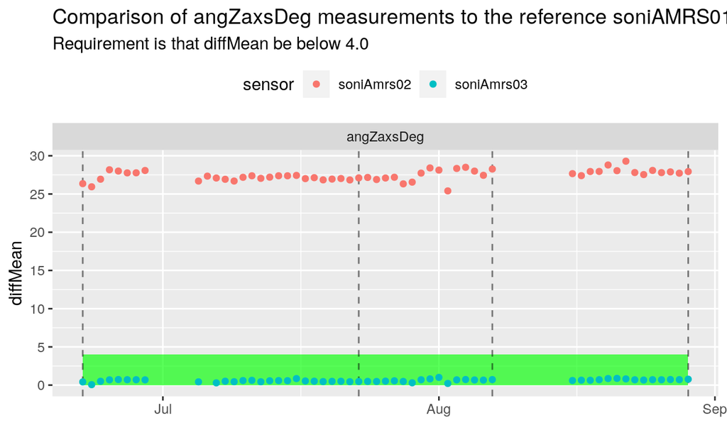

### Precision

To enable determining the 3-D wind vector with respect to the earth coordinate system, the AMRS shall be capable of measuring azimuth (around z-axis), pitch (around y-axis) and roll (around x-axis) with a precision of ≤ 0.1 deg.

Both sensors struggled with this comparison of precision.

|  | sensor | measurement | stat | 2021-06-22 | 2021-06-23 | 2021-06-24 | 2021-06-25 | 2021-06-26 | 2021-06-27 | 2021-06-28 | 2021-06-29 | 2021-07-05 | 2021-07-06 | 2021-07-07 | 2021-07-08 | 2021-07-09 | 2021-07-10 | 2021-07-11 | 2021-07-12 | 2021-07-13 | 2021-07-14 | 2021-07-15 | 2021-07-16 | 2021-07-17 | 2021-07-18 | 2021-07-19 | 2021-07-20 | 2021-07-21 | 2021-07-22 | … |
| --- | --- | --- | --- | --- | --- | --- | --- | --- | --- | --- | --- | --- | --- | --- | --- | --- | --- | --- | --- | --- | --- | --- | --- | --- | --- | --- | --- | --- | --- | --- |
| 1 | soniAmrs02 | angXaxsDeg | prcs | 0.10069 | 0.09851 | 0.09368 | 0.0957 | 0.09606 | 0.09621 | 0.09647 | 0.09539 | 0.09718 | 0.10005 | 0.09792 | 0.09583 | 0.09193 | 0.09735 | 0.09643 | 0.09704 | 0.09795 | 0.10091 | 0.09513 | 0.09649 | 0.09679 | 0.09931 | 0.09856 | 0.09704 | 0.09814 | 0.09892 | … |
| 2 | soniAmrs02 | angYaxsDeg | prcs | 0.1007 | 0.10224 | 0.10344 | 0.10191 | 0.10124 | 0.10382 | 0.1034 | 0.1013 | 0.09732 | 0.10024 | 0.1031 | 0.10545 | 0.10151 | 0.10573 | 0.10419 | 0.10253 | 0.10093 | 0.09953 | 0.1023 | 0.1008 | 0.10202 | 0.10244 | 0.10126 | 0.10223 | 0.10228 | 0.10243 | … |
| 3 | soniAmrs02 | angZaxsDeg | prcs | 0.33834 | 6.45834 | 0.31857 | 1.40176 | 0.5793 | 0.40812 | 0.42366 | 1.3548 | 0.30178 | 0.78025 | 0.62962 | 0.65652 | 0.33777 | 0.3091 | 0.1681 | 0.61942 | 0.32258 | 0.2874 | 0.47469 | 1.18008 | 0.4954 | 0.69694 | 0.5148 | 0.55846 | 0.37008 | 0.5141 | … |
| 4 | soniAmrs03 | angXaxsDeg | prcs | 0.11045 | 0.10868 | 0.10474 | 0.10286 | 0.10326 | 0.10755 | 0.10598 | 0.10525 | 0.1048 |  | 0.1208 | 0.10549 | 0.11116 | 0.10626 | 0.11184 | 0.10567 | 0.10767 | 0.10567 | 0.10624 | 0.10664 | 0.10831 | 0.10593 | 0.10563 | 0.10734 | 0.10527 | 0.10726 | … |
| 5 | soniAmrs03 | angYaxsDeg | prcs | 0.13689 | 0.13217 | 0.13604 | 0.12996 | 0.12977 | 0.13067 | 0.12724 | 0.12689 | 0.12009 |  | 0.14464 | 0.13548 | 0.13211 | 0.13198 | 0.12256 | 0.13213 | 0.133 | 0.13157 | 0.13158 | 0.13614 | 0.13349 | 0.13141 | 0.13613 | 0.13329 | 0.13463 | 0.13438 | … |
| 6 | soniAmrs03 | angZaxsDeg | prcs | 0.23028 | 3.45772 | 0.22268 | 0.23421 | 0.23455 | 0.23503 | 0.23324 | 0.22361 | 0.20525 |  | 0.24922 | 0.26146 | 0.21183 | 0.21806 | 0.22618 | 0.23794 | 0.24274 | 0.23054 | 0.24078 | 0.9582 | 0.26481 | 0.26773 | 0.24354 | 0.2564 | 0.2239 | 0.237 | … |

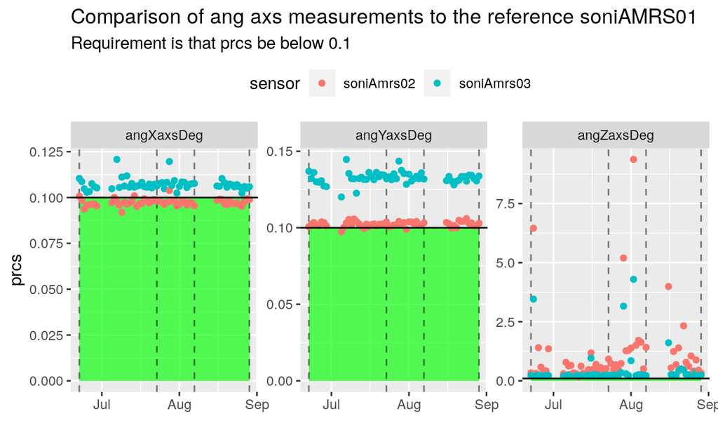

### Resolution

To enable determining the 3-D wind vector with respect to the earth coordinate system, the AMRS shall be capable of measuring azimuth (around z-axis), pitch (around y-axis) and roll (around x-axis) with a resolution of ≤ 0.05 deg.

Both settings **PASSED**

|  | sensor | measurement | stat | 2021-06-22 | 2021-06-23 | 2021-06-24 | 2021-06-25 | 2021-06-26 | 2021-06-27 | 2021-06-28 | 2021-06-29 | 2021-06-30 | 2021-07-01 | 2021-07-02 | 2021-07-03 | 2021-07-04 | 2021-07-05 | 2021-07-06 | 2021-07-07 | 2021-07-08 | 2021-07-09 | 2021-07-10 | 2021-07-11 | 2021-07-12 | 2021-07-13 | 2021-07-14 | 2021-07-15 | 2021-07-16 | 2021-07-17 | … |
| --- | --- | --- | --- | --- | --- | --- | --- | --- | --- | --- | --- | --- | --- | --- | --- | --- | --- | --- | --- | --- | --- | --- | --- | --- | --- | --- | --- | --- | --- | --- |
| 1 | soniAmrs02 | angXaxsDeg | reso | 0.00105601599999994 | 0.00106591 | 0.00111076199999999 | 0.00094884700000003 | 0.00103896900000011 | 0.00117814500000002 | 0.000984371000000039 | 0.00101125199999996 | 0.000936448000000034 | 0.00093024999999991 | 0.000915095499999879 | 0.00095784600000004 | 0.000987768000000111 | 0.000995874000000008 | 0.00098603999999991 | 0.000989853999999957 | 0.00102305400000002 | 0.00132760400000004 | 0.00118124499999994 | 0.000969111999999828 | 0.000999093000000006 | 0.000992774999999946 | 0.000961423000000017 | 0.000926463999999932 | 0.000971616000000119 | 0.000973998999999948 | … |
| 2 | soniAmrs02 | angYaxsDeg | reso | 0.000911429000000005 | 0.000973373600000001 | 0.0010905155 | 0.000891177999999992 | 0.000825807000000039 | 0.000952124999999998 | 0.000918794380000001 | 0.000937983000000003 | 0.00083810099999998 | 0.0008423257 | 0.00081372862 | 0.000856533600000001 | 0.000877402000000041 | 0.000885751099999998 | 0.000880479800000007 | 0.000877603449999997 | 0.000948504000000017 | 0.0013131797 | 0.00109066050000001 | 0.000830529200000017 | 0.000920258250000004 | 0.000902666999999975 | 0.000873157800000003 | 0.00083976999999999 | 0.00091683859999999 | 0.000920220999999999 | … |
| 3 | soniAmrs02 | angZaxsDeg | reso | 0.00199900000001207 | 0.00212099999998827 | 0.00233399999999051 | 0.00183100000000991 | 0.0019839999999931 | 0.00218200000000479 | 0.00215099999999779 | 0.00192200000000753 | 0.00201499999997168 | 0.00206000000000017 | 0.0019839999999931 | 0.00202999999999065 | 0.00204400000001215 | 0.00206000000000017 | 0.00196799999997666 | 0.0020449999999812 | 0.00208999999998127 | 0.00253299999999967 | 0.00241099999999506 | 0.00199899999998365 | 0.00202900000005002 | 0.00206000000000017 | 0.00207499999999072 | 0.00201400000000262 | 0.001923000000005 | 0.0020749999999623 | … |
| 4 | soniAmrs03 | angXaxsDeg | reso | 0.001550898 | 0.00163157279999999 | 0.00159671900000004 | 0.001426015 | 0.00159589920000001 | 0.00168473650000001 | 0.0015706867 | 0.001540333 | 0.00150059630000001 | 0.00151520899999999 | 0.0015424341 |  |  | 0.001505426445 |  | 0.001490958 | 0.00152624395 | 0.00179538099999998 | 0.0016646646 | 0.00138735025 | 0.00138328960000002 | 0.0014143195 | 0.001462765 | 0.00143656889999999 | 0.0015135892 | 0.0014667809 | … |
| 5 | soniAmrs03 | angYaxsDeg | reso | 0.00109857300000001 | 0.00115072799999999 | 0.00128239399999996 | 0.00102415699999997 | 0.000996380999999991 | 0.00112259300000001 | 0.00109067499999999 | 0.00108996 | 0.00102117699999993 | 0.00102633299999999 | 0.00102442499999994 |  |  | 0.00105835499999998 |  | 0.00108248000000005 | 0.00111651499999998 | 0.00150060700000004 | 0.00129443399999996 | 0.00101043999999999 | 0.00109376749999995 | 0.001136631 | 0.00109535400000005 | 0.00104136799999999 | 0.00110465300000001 | 0.00108216699999999 | … |
| 6 | soniAmrs03 | angZaxsDeg | reso | 0.00170899999999108 | 0.00178500000001236 | 0.00201499999998589 | 0.00167900000002419 | 0.00162500000000421 | 0.00180799999999692 | 0.00178499999998394 | 0.00175499999998863 | 0.00165499999998531 | 0.00169400000000053 | 0.00167000000000428 |  |  | 0.00170900000000529 |  | 0.00176199999999938 | 0.00183100000002412 | 0.00233400000000472 | 0.00216700000000003 | 0.0016859999999923 | 0.00170899999999108 | 0.00178600000000984 | 0.00176199999999938 | 0.00169300000000305 | 0.00170900000000529 | 0.00178499999999815 | … |

### Accuracy

To enable determining the 3-D wind vector with respect to the earth coordinate system, the AMRS shall be capable of measuring pitch (around y-axis) and roll (around x-axis) with an accuracy of ≤ 1 deg, including any internal alignment offsets.

Both settings **PASSED**

|  | sensor | measurement | stat | 2021-06-22 | 2021-06-23 | 2021-06-24 | 2021-06-25 | 2021-06-26 | 2021-06-27 | 2021-06-28 | 2021-06-29 | 2021-07-05 | 2021-07-06 | 2021-07-07 | 2021-07-08 | 2021-07-09 | 2021-07-10 | 2021-07-11 | 2021-07-12 | 2021-07-13 | 2021-07-14 | 2021-07-15 | 2021-07-16 | 2021-07-17 | 2021-07-18 | 2021-07-19 | 2021-07-20 | 2021-07-21 | 2021-07-22 | … |
| --- | --- | --- | --- | --- | --- | --- | --- | --- | --- | --- | --- | --- | --- | --- | --- | --- | --- | --- | --- | --- | --- | --- | --- | --- | --- | --- | --- | --- | --- | --- |
| 1 | soniAmrs02 | angXaxsDeg | diffMean | 0.24787 | 0.25085 | 0.25004 | 0.2543 | 0.25925 | 0.25987 | 0.26115 | 0.25608 | 0.24758 | 0.24214 | 0.25322 | 0.25966 | 0.24797 | 0.24791 | 0.25724 | 0.24428 | 0.24003 | 0.24407 | 0.24238 | 0.2405 | 0.23667 | 0.24004 | 0.22416 | 0.2324 | 0.23216 | 0.23633 | … |
| 2 | soniAmrs02 | angYaxsDeg | diffMean | 0.3579 | 0.34035 | 0.33977 | 0.34563 | 0.35731 | 0.35531 | 0.35502 | 0.35232 | 0.35065 | 0.34625 | 0.34808 | 0.33938 | 0.33339 | 0.332 | 0.34029 | 0.34019 | 0.33395 | 0.33685 | 0.33927 | 0.33661 | 0.33924 | 0.33897 | 0.33084 | 0.32946 | 0.33216 | 0.33704 | … |
| 3 | soniAmrs03 | angXaxsDeg | diffMean | 0.38034 | 0.38483 | 0.37586 | 0.37925 | 0.38058 | 0.3716 | 0.37513 | 0.37758 | 0.37239 |  | 0.37693 | 0.37555 | 0.37656 | 0.37435 | 0.37157 | 0.37887 | 0.38107 | 0.3844 | 0.38669 | 0.38462 | 0.38186 | 0.38363 | 0.39179 | 0.39239 | 0.3889 | 0.38743 | … |
| 4 | soniAmrs03 | angYaxsDeg | diffMean | 0.08417 | 0.08168 | 0.07893 | 0.10234 | 0.11458 | 0.11033 | 0.10943 | 0.10939 | 0.08209 |  | 0.07543 | 0.09101 | 0.0899 | 0.08371 | 0.09546 | 0.08272 | 0.09041 | 0.10168 | 0.10798 | 0.09813 | 0.09273 | 0.09517 | 0.09619 | 0.09655 | 0.09524 | 0.09478 | … |

## Supplemental Plots

### accXaxs + accYaxs + accZaxs